# Project

#### Decision Tree Regressor for the merged data set "X_NAB_Combine" (NBA Draft data and Draft Combine Metrics)

```python
# Names of split data set = X_NBA_Combine_train, X_NBA_Combine_test, y_NBA_Combine_train, y_NBA_Combine_test
```

```python
import numpy as np
import pandas as pd
from sklearn.model_selection import train_test_split
from sklearn.preprocessing import StandardScaler
from sklearn.tree import DecisionTreeRegressor
from sklearn.metrics import mean_squared_error, r2_score
```

```python
# Feature Scaling

scaler = StandardScaler()

# Scale the training data
X_NBA_Combine_train_scaled = scaler.fit_transform(X_NBA_Combine_train)

# Scale the test data
X_NBA_Combine_test_scaled = scaler.transform(X_NBA_Combine_test)
```

```python
# Initialize the Decision Tree Regressor
model_nba_combine_dtr = DecisionTreeRegressor(random_state=42)

# Train the model
model_nba_combine_dtr.fit(X_NBA_Combine_train_scaled, y_NBA_Combine_train)
```

```
DecisionTreeRegressor(random_state=42)
```

```python
# Predict BPM values for the test set
y_pred_nba_combine_dtr = model_nba_combine_dtr.predict(X_NBA_Combine_test_scaled)

# Evaluate the model's performance
mse_nba_combine_dtr = mean_squared_error(y_NBA_Combine_test, y_pred_nba_combine_dtr)
r2_nba_combine_dtr = r2_score(y_NBA_Combine_test, y_pred_nba_combine_dtr)

print(f'Mean Squared Error: {mse_nba_combine_dtr}')
print(f'R-squared: {r2_nba_combine_dtr}')
```

```
Mean Squared Error: 6.35635294117647
R-squared: 0.5085469079365705
```

```python
# Hyperparameter Tuning
from sklearn.model_selection import GridSearchCV

# Define the parameter grid
param_grid = {
    'max_depth': [3, 5, 10, None],
    'min_samples_split': [2, 5, 10],
    'min_samples_leaf': [1, 2, 4]
}

# Initialize GridSearchCV
grid_search = GridSearchCV(DecisionTreeRegressor(random_state=42), param_grid, cv=5, scoring='neg_mean_squared_error')

# Fit the grid search
grid_search.fit(X_NBA_Combine_train_scaled, y_NBA_Combine_train)

# Best parameters
print(f"Best Parameters: {grid_search.best_params_}")

# Use the best model
best_model_nba_combine_dtr_tune = grid_search.best_estimator_

# Predict using the best model
y_pred_best_nba_combine_dtr_tune = best_model_nba_combine_dtr_tune.predict(X_NBA_Combine_test_scaled)

# Evaluate the best model
mse_best_nba_combine_dtr_tune = mean_squared_error(y_NBA_Combine_test, y_pred_best_nba_combine_dtr_tune)
r2_best_nba_combine_dtr_tune = r2_score(y_NBA_Combine_test, y_pred_best_nba_combine_dtr_tune)

print(f"Best Mean Squared Error: {mse_best_nba_combine_dtr_tune}")
print(f"Best R-squared: {r2_best_nba_combine_dtr_tune}")
```

```
Best Parameters: {'max_depth': 3, 'min_samples_leaf': 1, 'min_samples_split': 5}
Best Mean Squared Error: 3.605880741282562
Best R-squared: 0.7212047134079859
```

```python
# The model performed better with the tuned hyparparameters.
```

###### After analysing the merged data set of NBA Draft Data and Draft Combine Metrics, we have noticed that Random Forest Regressor with tuned hyperparameters performed better than any models in terms of predicting BPM. As it performs better, we we will find the feature importance of random forest regressor to understand which features of the merged data set play an important role in predicting BMP.

```python
# Get feature importance for the model "Random Forest Regressor"
importances = rf_nba_combine_tune.feature_importances_
feature_names = X_NBA_Combine.columns

# Display feature importances
for name, importance in zip(feature_names, importances):
    print(f'{name}: {importance:.4f}')
```

```
TOTG: 0.1873
TOTMP: 0.0599
TOTPTS: 0.1464
TRB: 0.0675
TOTAST: 0.0633
FG%: 0.2209
3P%: 0.0109
FT%: 0.0143
MPPG: 0.0375
PTSPG: 0.1065
TRBPG: 0.0095
ASTPG: 0.0104
Standing Reach_Inches: 0.0068
Height Without Shoes_Inches: 0.0035
Wingspan_Inches: 0.0042
Standing Vertical Leap_Inches: 0.0149
Max Vertical Leap_Inches: 0.0078
Shuttle Run_Secs: 0.0075
Lane Agility_Secs: 0.0096
Three Quarter Sprint_Secs: 0.0113
```

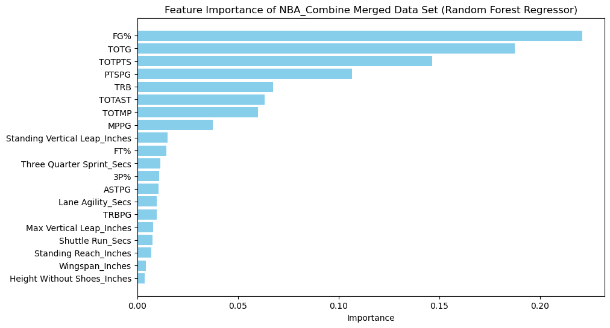

```python
import matplotlib.pyplot as plt
import pandas as pd
# rf stands for "random forest"
# Define feature names and their importance values
features_nba_combine_rf = [
    'TOTG', 'TOTMP', 'TOTPTS', 'TRB', 'TOTAST', 'FG%', '3P%', 'FT%',
    'MPPG', 'PTSPG', 'TRBPG', 'ASTPG', 'Standing Reach_Inches',
    'Height Without Shoes_Inches', 'Wingspan_Inches',
    'Standing Vertical Leap_Inches', 'Max Vertical Leap_Inches',
    'Shuttle Run_Secs', 'Lane Agility_Secs', 'Three Quarter Sprint_Secs'
]
importances_nba_combine_rf = [
   0.1873, 0.0599, 0.1464, 0.0675, 0.0633, 0.2209, 0.0109, 0.0143,
   0.0375, 0.1065, 0.0095, 0.0104, 0.0068, 0.0035, 0.0042, 0.0149,
   0.0078, 0.0075, 0.0096, 0.0113
]

# Create a DataFrame for easy plotting
df_importances_nba_combine_rf = pd.DataFrame({
    'Feature': features_nba_combine_rf,
    'Importance': importances_nba_combine_rf
})

# Sort the DataFrame by importance
df_importances_nba_combine_rf = df_importances_nba_combine_rf.sort_values(by='Importance', ascending=False)

# Plot the bar chart
plt.figure(figsize=(10, 6))
plt.barh(df_importances_nba_combine_rf['Feature'], df_importances_nba_combine_rf['Importance'], color='skyblue')
plt.xlabel('Importance')
plt.title('Feature Importance of NBA_Combine Merged Data Set (Random Forest Regressor)')
plt.gca().invert_yaxis()  # Invert y-axis to have the highest importance at the top
plt.show()
```

#### Now we will analyse college stats of NBA players by using machine learning models to understand the improtance of college stast in predicting BPM.

```python
# Importing College Stats of the nba drafted players
College_Stats = pd.read_csv("C:\\Users\\Sajal Nandi\\Downloads\\SN_30111888_Project\\30111888_College-Stats-of-NBA-Players.csv")
```

```python
College_Stats
```

|  | Rk | Pk | Draft Year | Player ID | Team | Player Name | College | TOTG | TOTMP | TOTFG | ... | TOTTOV | TOTPF | TOTPTS | FG% | 3P% | FT% | MPPG | PTSPG | TRBPG | ASTPG |
| --- | --- | --- | --- | --- | --- | --- | --- | --- | --- | --- | --- | --- | --- | --- | --- | --- | --- | --- | --- | --- | --- |
| 0 | 1 | 1 | 2000 | 200001 | NJN | Kenyon Martin | Cincinnati | 116 | 2900.0 | 513 | ... | 191.0 | 340.0 | 1279 | 0.586 | 0.222 | 0.581 | 25.0 | 11.0 | 7.5 | 1.2 |
| 1 | 2 | 2 | 2000 | 200002 | VAN | Stromile Swift | LSU | 50 | 1332.0 | 253 | ... | 126.0 | 131.0 | 671 | 0.560 | 0.242 | 0.613 | 26.6 | 13.4 | 7.0 | 0.7 |
| 2 | 3 | 3 | 2000 | 200003 | CHI | Marcus Fizer | Iowa State | 97 | 3020.0 | 690 | ... | 225.0 | 257.0 | 1830 | 0.511 | 0.292 | 0.702 | 31.1 | 18.9 | 7.4 | 1.0 |
| 3 | 4 | 4 | 2000 | 200004 | ORL | Mike Miller | Florida | 65 | 1735.0 | 290 | ... | 140.0 | 122.0 | 862 | 0.483 | 0.345 | 0.718 | 26.7 | 13.3 | 6.0 | 2.3 |
| 4 | 5 | 5 | 2000 | 200005 | ATL | DerMarr Johnson | Cincinnati | 32 | 879.0 | 140 | ... | 46.0 | 64.0 | 402 | 0.478 | 0.371 | 0.737 | 27.5 | 12.6 | 3.8 | 1.4 |
| ... | ... | ... | ... | ... | ... | ... | ... | ... | ... | ... | ... | ... | ... | ... | ... | ... | ... | ... | ... | ... | ... |
| 418 | 43 | 43 | 2010 | 201043 | LAC | Willie Warren | Oklahoma | 57 | 1806.0 | 278 | ... | 160.0 | 129.0 | 868 | 0.459 | 0.350 | 0.788 | 31.7 | 15.2 | 2.6 | 3.5 |
| 419 | 44 | 44 | 2010 | 201044 | UTA | Jeremy Evans | Western Kentucky | 134 | 3150.0 | 427 | ... | 136.0 | 328.0 | 1065 | 0.639 | 0.364 | 0.684 | 23.5 | 7.9 | 5.9 | 0.5 |
| 420 | 45 | 45 | 2010 | 201045 | MIN | Hamady N'Diaye | Rutgers University | 124 | 2744.0 | 267 | ... | 169.0 | 333.0 | 718 | 0.539 | 0.000 | 0.592 | 22.1 | 5.8 | 5.5 | 0.4 |
| 421 | 46 | 46 | 2010 | 201046 | IND | Ryan Reid | Florida State | 126 | 2539.0 | 236 | ... | 206.0 | 244.0 | 624 | 0.495 | 1.000 | 0.604 | 20.2 | 5.0 | 3.9 | 0.7 |
| 422 | 47 | 47 | 2010 | 201047 | LAL | Derrick Caracter | Texas-El Paso | 79 | 1553.0 | 314 | ... | 170.0 | 241.0 | 810 | 0.563 | 0.313 | 0.628 | 19.7 | 10.3 | 5.6 | 0.6 |

423 rows × 30 columns

```python
# Finding Columnwise Empty Cell
empty_cells = College_Stats.isna().sum() + (College_Stats == '').sum()
```

```python
empty_cells
```

```
Rk              0
Pk              0
Draft Year      0
Player ID       0
Team            0
Player Name     0
College         0
TOTG            0
TOTMP           2
TOTFG           0
TOTFGA          0
TOT3P           0
TOT3PA          0
TOTFT           0
TOTFTA          0
TOTORB          4
TRB             0
TOTAST          0
TOTSTL          2
TOTBLK          2
TOTTOV          2
TOTPF           2
TOTPTS          0
FG%             0
3P%            33
FT%             0
MPPG            2
PTSPG           0
TRBPG           0
ASTPG           0
dtype: int64
```

```python
# Replace empty cells with NAN values
import numpy as np
College_Stats.replace('', np.nan, inplace=True)
```

```python
# Replacing NaN values with zero
College_Stats.fillna(0, inplace=True)
```

```python
# Checking empty cells columnwise again
empty_cells = College_Stats.isna().sum() + (College_Stats == '').sum()
```

```python
empty_cells
```

```
Rk             0
Pk             0
Draft Year     0
Player ID      0
Team           0
Player Name    0
College        0
TOTG           0
TOTMP          0
TOTFG          0
TOTFGA         0
TOT3P          0
TOT3PA         0
TOTFT          0
TOTFTA         0
TOTORB         0
TRB            0
TOTAST         0
TOTSTL         0
TOTBLK         0
TOTTOV         0
TOTPF          0
TOTPTS         0
FG%            0
3P%            0
FT%            0
MPPG           0
PTSPG          0
TRBPG          0
ASTPG          0
dtype: int64
```

```python
College_Stats = College_Stats.drop(["Rk", "Pk", "Draft Year", "Team", "Player Name", "College"], axis=1)
```

```python
College_Stats
```

|  | Player ID | TOTG | TOTMP | TOTFG | TOTFGA | TOT3P | TOT3PA | TOTFT | TOTFTA | TOTORB | ... | TOTTOV | TOTPF | TOTPTS | FG% | 3P% | FT% | MPPG | PTSPG | TRBPG | ASTPG |
| --- | --- | --- | --- | --- | --- | --- | --- | --- | --- | --- | --- | --- | --- | --- | --- | --- | --- | --- | --- | --- | --- |
| 0 | 200001 | 116 | 2900.0 | 513 | 875 | 2 | 9 | 251 | 432 | 76.0 | ... | 191.0 | 340.0 | 1279 | 0.586 | 0.222 | 0.581 | 25.0 | 11.0 | 7.5 | 1.2 |
| 1 | 200002 | 50 | 1332.0 | 253 | 452 | 8 | 33 | 157 | 256 | 103.0 | ... | 126.0 | 131.0 | 671 | 0.560 | 0.242 | 0.613 | 26.6 | 13.4 | 7.0 | 0.7 |
| 2 | 200003 | 97 | 3020.0 | 690 | 1349 | 21 | 72 | 429 | 611 | 100.0 | ... | 225.0 | 257.0 | 1830 | 0.511 | 0.292 | 0.702 | 31.1 | 18.9 | 7.4 | 1.0 |
| 3 | 200004 | 65 | 1735.0 | 290 | 601 | 78 | 226 | 204 | 284 | 80.0 | ... | 140.0 | 122.0 | 862 | 0.483 | 0.345 | 0.718 | 26.7 | 13.3 | 6.0 | 2.3 |
| 4 | 200005 | 32 | 879.0 | 140 | 293 | 52 | 140 | 70 | 95 | 37.0 | ... | 46.0 | 64.0 | 402 | 0.478 | 0.371 | 0.737 | 27.5 | 12.6 | 3.8 | 1.4 |
| ... | ... | ... | ... | ... | ... | ... | ... | ... | ... | ... | ... | ... | ... | ... | ... | ... | ... | ... | ... | ... | ... |
| 418 | 201043 | 57 | 1806.0 | 278 | 606 | 97 | 277 | 215 | 273 | 32.0 | ... | 160.0 | 129.0 | 868 | 0.459 | 0.350 | 0.788 | 31.7 | 15.2 | 2.6 | 3.5 |
| 419 | 201044 | 134 | 3150.0 | 427 | 668 | 12 | 33 | 199 | 291 | 321.0 | ... | 136.0 | 328.0 | 1065 | 0.639 | 0.364 | 0.684 | 23.5 | 7.9 | 5.9 | 0.5 |
| 420 | 201045 | 124 | 2744.0 | 267 | 495 | 0 | 2 | 184 | 311 | 219.0 | ... | 169.0 | 333.0 | 718 | 0.539 | 0.000 | 0.592 | 22.1 | 5.8 | 5.5 | 0.4 |
| 421 | 201046 | 126 | 2539.0 | 236 | 477 | 1 | 1 | 151 | 250 | 213.0 | ... | 206.0 | 244.0 | 624 | 0.495 | 1.000 | 0.604 | 20.2 | 5.0 | 3.9 | 0.7 |
| 422 | 201047 | 79 | 1553.0 | 314 | 558 | 5 | 16 | 177 | 282 | 186.0 | ... | 170.0 | 241.0 | 810 | 0.563 | 0.313 | 0.628 | 19.7 | 10.3 | 5.6 | 0.6 |

423 rows × 24 columns

```python
X_college = pd.DataFrame(College_Stats) # Making a new data set using the original data set.
```

```python
X_college
```

|  | Player ID | TOTG | TOTMP | TOTFG | TOTFGA | TOT3P | TOT3PA | TOTFT | TOTFTA | TOTORB | ... | TOTTOV | TOTPF | TOTPTS | FG% | 3P% | FT% | MPPG | PTSPG | TRBPG | ASTPG |
| --- | --- | --- | --- | --- | --- | --- | --- | --- | --- | --- | --- | --- | --- | --- | --- | --- | --- | --- | --- | --- | --- |
| 0 | 200001 | 116 | 2900.0 | 513 | 875 | 2 | 9 | 251 | 432 | 76.0 | ... | 191.0 | 340.0 | 1279 | 0.586 | 0.222 | 0.581 | 25.0 | 11.0 | 7.5 | 1.2 |
| 1 | 200002 | 50 | 1332.0 | 253 | 452 | 8 | 33 | 157 | 256 | 103.0 | ... | 126.0 | 131.0 | 671 | 0.560 | 0.242 | 0.613 | 26.6 | 13.4 | 7.0 | 0.7 |
| 2 | 200003 | 97 | 3020.0 | 690 | 1349 | 21 | 72 | 429 | 611 | 100.0 | ... | 225.0 | 257.0 | 1830 | 0.511 | 0.292 | 0.702 | 31.1 | 18.9 | 7.4 | 1.0 |
| 3 | 200004 | 65 | 1735.0 | 290 | 601 | 78 | 226 | 204 | 284 | 80.0 | ... | 140.0 | 122.0 | 862 | 0.483 | 0.345 | 0.718 | 26.7 | 13.3 | 6.0 | 2.3 |
| 4 | 200005 | 32 | 879.0 | 140 | 293 | 52 | 140 | 70 | 95 | 37.0 | ... | 46.0 | 64.0 | 402 | 0.478 | 0.371 | 0.737 | 27.5 | 12.6 | 3.8 | 1.4 |
| ... | ... | ... | ... | ... | ... | ... | ... | ... | ... | ... | ... | ... | ... | ... | ... | ... | ... | ... | ... | ... | ... |
| 418 | 201043 | 57 | 1806.0 | 278 | 606 | 97 | 277 | 215 | 273 | 32.0 | ... | 160.0 | 129.0 | 868 | 0.459 | 0.350 | 0.788 | 31.7 | 15.2 | 2.6 | 3.5 |
| 419 | 201044 | 134 | 3150.0 | 427 | 668 | 12 | 33 | 199 | 291 | 321.0 | ... | 136.0 | 328.0 | 1065 | 0.639 | 0.364 | 0.684 | 23.5 | 7.9 | 5.9 | 0.5 |
| 420 | 201045 | 124 | 2744.0 | 267 | 495 | 0 | 2 | 184 | 311 | 219.0 | ... | 169.0 | 333.0 | 718 | 0.539 | 0.000 | 0.592 | 22.1 | 5.8 | 5.5 | 0.4 |
| 421 | 201046 | 126 | 2539.0 | 236 | 477 | 1 | 1 | 151 | 250 | 213.0 | ... | 206.0 | 244.0 | 624 | 0.495 | 1.000 | 0.604 | 20.2 | 5.0 | 3.9 | 0.7 |
| 422 | 201047 | 79 | 1553.0 | 314 | 558 | 5 | 16 | 177 | 282 | 186.0 | ... | 170.0 | 241.0 | 810 | 0.563 | 0.313 | 0.628 | 19.7 | 10.3 | 5.6 | 0.6 |

423 rows × 24 columns

```python
X_college = X_college.drop(["Player ID"], axis=1)
```

```python
X_college # This data set will be used for the analysis along with target variable.
```

|  | TOTG | TOTMP | TOTFG | TOTFGA | TOT3P | TOT3PA | TOTFT | TOTFTA | TOTORB | TRB | ... | TOTTOV | TOTPF | TOTPTS | FG% | 3P% | FT% | MPPG | PTSPG | TRBPG | ASTPG |
| --- | --- | --- | --- | --- | --- | --- | --- | --- | --- | --- | --- | --- | --- | --- | --- | --- | --- | --- | --- | --- | --- |
| 0 | 116 | 2900.0 | 513 | 875 | 2 | 9 | 251 | 432 | 76.0 | 869 | ... | 191.0 | 340.0 | 1279 | 0.586 | 0.222 | 0.581 | 25.0 | 11.0 | 7.5 | 1.2 |
| 1 | 50 | 1332.0 | 253 | 452 | 8 | 33 | 157 | 256 | 103.0 | 348 | ... | 126.0 | 131.0 | 671 | 0.560 | 0.242 | 0.613 | 26.6 | 13.4 | 7.0 | 0.7 |
| 2 | 97 | 3020.0 | 690 | 1349 | 21 | 72 | 429 | 611 | 100.0 | 716 | ... | 225.0 | 257.0 | 1830 | 0.511 | 0.292 | 0.702 | 31.1 | 18.9 | 7.4 | 1.0 |
| 3 | 65 | 1735.0 | 290 | 601 | 78 | 226 | 204 | 284 | 80.0 | 389 | ... | 140.0 | 122.0 | 862 | 0.483 | 0.345 | 0.718 | 26.7 | 13.3 | 6.0 | 2.3 |
| 4 | 32 | 879.0 | 140 | 293 | 52 | 140 | 70 | 95 | 37.0 | 123 | ... | 46.0 | 64.0 | 402 | 0.478 | 0.371 | 0.737 | 27.5 | 12.6 | 3.8 | 1.4 |
| ... | ... | ... | ... | ... | ... | ... | ... | ... | ... | ... | ... | ... | ... | ... | ... | ... | ... | ... | ... | ... | ... |
| 418 | 57 | 1806.0 | 278 | 606 | 97 | 277 | 215 | 273 | 32.0 | 149 | ... | 160.0 | 129.0 | 868 | 0.459 | 0.350 | 0.788 | 31.7 | 15.2 | 2.6 | 3.5 |
| 419 | 134 | 3150.0 | 427 | 668 | 12 | 33 | 199 | 291 | 321.0 | 788 | ... | 136.0 | 328.0 | 1065 | 0.639 | 0.364 | 0.684 | 23.5 | 7.9 | 5.9 | 0.5 |
| 420 | 124 | 2744.0 | 267 | 495 | 0 | 2 | 184 | 311 | 219.0 | 681 | ... | 169.0 | 333.0 | 718 | 0.539 | 0.000 | 0.592 | 22.1 | 5.8 | 5.5 | 0.4 |
| 421 | 126 | 2539.0 | 236 | 477 | 1 | 1 | 151 | 250 | 213.0 | 490 | ... | 206.0 | 244.0 | 624 | 0.495 | 1.000 | 0.604 | 20.2 | 5.0 | 3.9 | 0.7 |
| 422 | 79 | 1553.0 | 314 | 558 | 5 | 16 | 177 | 282 | 186.0 | 440 | ... | 170.0 | 241.0 | 810 | 0.563 | 0.313 | 0.628 | 19.7 | 10.3 | 5.6 | 0.6 |

423 rows × 23 columns

```python
y_college = pd.DataFrame(y_nba_o) # Making a new target variable using the original target variable.
```

```python
y_college
```

|  | BPM |
| --- | --- |
| 0 | 0.1 |
| 1 | -1.6 |
| 2 | -3.7 |
| 3 | 0.8 |
| 4 | -1.6 |
| ... | ... |
| 418 | -2.7 |
| 419 | 0.9 |
| 420 | -7.3 |
| 421 | -2.0 |
| 422 | -7.1 |

423 rows × 1 columns

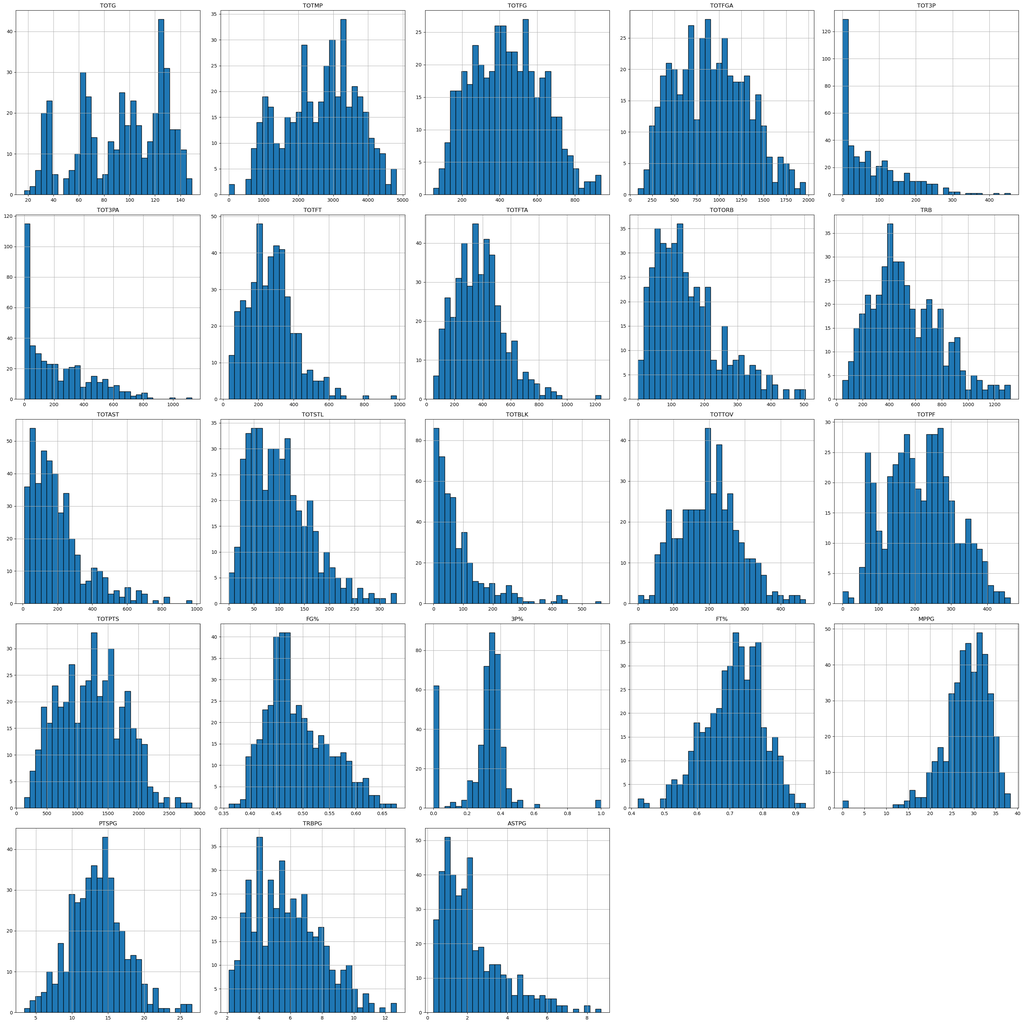

```python
import matplotlib.pyplot as plt
import seaborn as sns

# Set the figure size to handle all features
X_college.hist(figsize=(30, 30), bins=30, edgecolor='black')

# Display the plots
plt.tight_layout()  # Adjust subplots to fit into figure area
plt.show()
```

```python
skewness_per_column = X_college.skew()
```

```python
skewness_per_column
```

```
TOTG     -0.389833
TOTMP    -0.195784
TOTFG     0.189719
TOTFGA    0.240272
TOT3P     1.190534
TOT3PA    0.979787
TOTFT     0.890422
TOTFTA    0.761164
TOTORB    1.006073
TRB       0.626659
TOTAST    1.549362
TOTSTL    0.894972
TOTBLK    2.074602
TOTTOV    0.285270
TOTPF     0.145308
TOTPTS    0.200197
FG%       0.625754
3P%      -0.071383
FT%      -0.385470
MPPG     -1.266075
PTSPG     0.268923
TRBPG     0.515243
ASTPG     1.313304
dtype: float64
```

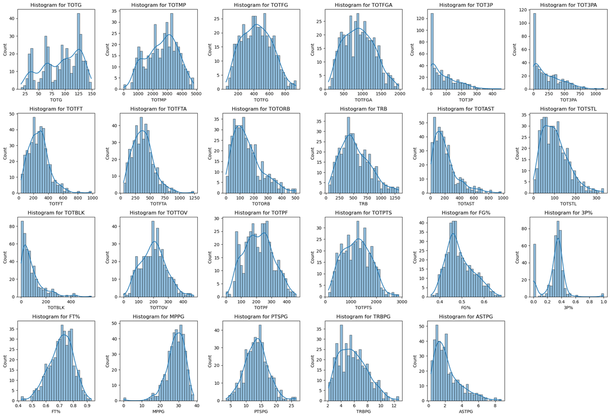

```python
# Set up the plot grid
num_columns = X_college.select_dtypes(include=['float64', 'int64']).columns  # Only numeric features
plt.figure(figsize=(20, 20))

for i, column in enumerate(num_columns, 1):
    plt.subplot(6, 6, i)  # Adjust 6x6 grid based on the number of features
    sns.histplot(X_college[column], kde=True, bins=30, edgecolor='black')
    plt.title(f'Histogram for {column}')

plt.tight_layout()
plt.show()
```

```python
# Spliting college stat data set
from sklearn.model_selection import train_test_split
X_college_train, X_college_test, y_college_train, y_college_test = train_test_split(X_college, y_college, test_size=0.2, random_state=42)
```

#### Random Forest Regressor for just college stats data

```python
from sklearn.ensemble import RandomForestRegressor
from sklearn.model_selection import train_test_split
from sklearn.metrics import mean_squared_error, r2_score
import pandas as pd
import numpy as np
```

```python
# Initializing the random forest regressor with 100 trees
rf_college = RandomForestRegressor(n_estimators=100, random_state=42)
```

```python
# Fitting the model on training data
rf_college.fit(X_college_train, y_college_train)
```

```
C:\Users\Sajal Nandi\AppData\Local\Temp\ipykernel_5836\1626599269.py:2: DataConversionWarning: A column-vector y was passed when a 1d array was expected. Please change the shape of y to (n_samples,), for example using ravel().
  rf_college.fit(X_college_train, y_college_train)
```

```
RandomForestRegressor(random_state=42)
```

```python
# Predicting the BPM values for the test set
y_pred_rf_college = rf_college.predict(X_college_test)
```

```python
# Evaluating the model
mse_rf_college = mean_squared_error(y_college_test, y_pred_rf_college)
r2_rf_college = r2_score(y_college_test, y_pred_rf_college)

print(f'Mean Squared Error: {mse_rf_college}')
print(f'R-squared: {r2_rf_college}')
```

```
Mean Squared Error: 11.62354925882353
R-squared: 0.10130395891089106
```

```python
# Hyperparameter Tuning for the Random Forest Regressor Model
from sklearn.model_selection import GridSearchCV
```

```python
param_grid = {
    'n_estimators': [100, 200, 300],
    'max_depth': [10, 20, 30],
    'min_samples_split': [2, 5, 10]
}

grid_search = GridSearchCV(estimator=rf, param_grid=param_grid, cv=5)
grid_search.fit(X_college_train, y_college_train)

print(grid_search.best_params_)
```

[output not shown]

[output cut: 246 more lines]

```
{'max_depth': 10, 'min_samples_split': 10, 'n_estimators': 200}
```

```python
# Initializing the random forest regressor with new parameters
rf_college_tune = RandomForestRegressor(n_estimators=200, max_depth=10, min_samples_split=10, random_state=42)
```

```python
# Fitting the model on training data
rf_college_tune.fit(X_college_train, y_college_train)
```

```
C:\Users\Sajal Nandi\AppData\Local\Temp\ipykernel_5836\3562977219.py:2: DataConversionWarning: A column-vector y was passed when a 1d array was expected. Please change the shape of y to (n_samples,), for example using ravel().
  rf_college_tune.fit(X_college_train, y_college_train)
```

```
RandomForestRegressor(max_depth=10, min_samples_split=10, n_estimators=200,
                      random_state=42)
```

```python
# Predicting the BPM values for the test set
y_pred_rf_college_tune = rf_college_tune.predict(X_college_test)   #rf means Random Forest
```

```python
# Evaluating the model
mse_rf_college_tune = mean_squared_error(y_college_test, y_pred_rf_college_tune)
r2_rf_college_tune = r2_score(y_college_test, y_pred_rf_college_tune)

print(f'Mean Squared Error: {mse_rf_college_tune}')
print(f'R-squared: {r2_rf_college_tune}')
```

```
Mean Squared Error: 12.027035462553942
R-squared: 0.07010768263999789
```

```python
# Random forest regressor model performed better without tuning.
```

### XGBoost Model for college stats data set

```python
# Names of the split data set = X_college_train, X_college_test, y_college_train, y_college_test
```

```python
import xgboost as xgb
from sklearn.model_selection import train_test_split
from sklearn.preprocessing import StandardScaler
from sklearn.metrics import mean_squared_error, r2_score
import pandas as pd
import numpy as np
```

```python
# Feature Scaling

scaler = StandardScaler()

# Scale the training data
X_college_train_scaled = scaler.fit_transform(X_college_train)

# Scale the test data
X_college_test_scaled = scaler.transform(X_college_test)
```

```python
# Initialize the XGBoost regressor
xgb_model_college = xgb.XGBRegressor(
    n_estimators=100,  # Number of boosting rounds (trees)
    learning_rate=0.1, # Shrinkage rate
    max_depth=3,       # Maximum depth of trees
    subsample=0.8,     # Fraction of samples used for fitting individual base learners
    random_state=42
)
```

```python
xgb_model_college.fit(X_college_train_scaled, y_college_train)
```

```
XGBRegressor(base_score=None, booster=None, callbacks=None,
             colsample_bylevel=None, colsample_bynode=None,
             colsample_bytree=None, device=None, early_stopping_rounds=None,
             enable_categorical=False, eval_metric=None, feature_types=None,
             gamma=None, grow_policy=None, importance_type=None,
             interaction_constraints=None, learning_rate=0.1, max_bin=None,
             max_cat_threshold=None, max_cat_to_onehot=None,
             max_delta_step=None, max_depth=3, max_leaves=None,
             min_child_weight=None, missing=nan, monotone_constraints=None,
             multi_strategy=None, n_estimators=100, n_jobs=None,
             num_parallel_tree=None, random_state=42, ...)
```

```python
# Predict BPM values for the test set
y_pred_xgb_college = xgb_model_college.predict(X_college_test_scaled)
```

```python
# Evaluate the model
mse_xgb_college = mean_squared_error(y_college_test, y_pred_xgb_college)
r2_xgb_college = r2_score(y_college_test, y_pred_xgb_college)
```

```python
print(f'Mean Squared Error: {mse_xgb_college}')
print(f'R-squared: {r2_xgb_college}')
```

```
Mean Squared Error: 11.235751317466056
R-squared: 0.13128726838720362
```

```python
# Hyperparameter Tuning

from sklearn.model_selection import GridSearchCV

# Define the parameter grid
param_grid = {
    'n_estimators': [100, 200, 300],
    'learning_rate': [0.01, 0.1, 0.2],
    'max_depth': [3, 5, 7],
    'subsample': [0.8, 1.0]
}

# Initialize GridSearchCV with XGBRegressor
grid_search = GridSearchCV(estimator=xgb.XGBRegressor(random_state=42), param_grid=param_grid, cv=5, scoring='r2')

# Fit the grid search to the scaled training data
grid_search.fit(X_college_train_scaled, y_college_train)

# Print the best parameters
print(f'Best parameters: {grid_search.best_params_}')
```

```
Best parameters: {'learning_rate': 0.01, 'max_depth': 7, 'n_estimators': 100, 'subsample': 0.8}
```

```python
# Use the best model for prediction
best_model_xgb_college = grid_search.best_estimator_
y_pred_best_xgb_college = best_model_xgb_college.predict(X_college_test_scaled)
```

```python
# Evaluate the best model
mse_best_xbg_college_tune = mean_squared_error(y_college_test, y_pred_best_xgb_college)
r2_best_xgb_college_tune = r2_score(y_college_test, y_pred_best_xgb_college)

print(f'Best Mean Squared Error: {mse_best_xbg_college_tune}')
print(f'Best R-squared: {r2_best_xgb_college_tune}')
```

```
Best Mean Squared Error: 12.13479099403958
Best R-squared: 0.061776365983161496
```

```python
# The model without tuned parameters performs better than the model with tune parameters.
```

### Artificial Neural Network (ANN) for college stats data

```python
# Names of the split data set = X_college_train, X_college_test, y_college_train, y_college_test
```

```python
import numpy as np
import pandas as pd
from sklearn.model_selection import train_test_split
from sklearn.preprocessing import StandardScaler
from sklearn.metrics import mean_squared_error, r2_score
import tensorflow as tf
from tensorflow.keras.models import Sequential
from tensorflow.keras.layers import Dense
from tensorflow.keras.optimizers import Adam
```

```python
# Feature Scaling

scaler = StandardScaler()

# Scale the training data
X_college_train_scaled = scaler.fit_transform(X_college_train)

# Scale the test data
X_college_test_scaled = scaler.transform(X_college_test)
```

```python
# Initialize the model
model_college_ann = Sequential()

# Input layer and first hidden layer with 64 neurons and ReLU activation
model_college_ann.add(Dense(64, input_dim=X_college_train_scaled.shape[1], activation='relu'))

# Additional hidden layers
model_college_ann.add(Dense(128, activation='relu'))
model_college_ann.add(Dense(64, activation='relu'))

# Output layer with a single neuron (since this is a regression problem)
model_college_ann.add(Dense(1, activation='linear'))

# Compile the model with mean squared error loss and the Adam optimizer
model_college_ann.compile(optimizer=Adam(learning_rate=0.001), loss='mean_squared_error', metrics=['mse'])
```

```python
# Train the model
history_college = model_college_ann.fit(X_college_train_scaled, y_college_train, validation_split=0.2, epochs=100, batch_size=32, verbose=1)
```

```python
# Predict BPM values for the test set
y_pred_college_ann = model_college_ann.predict(X_college_test_scaled)

# Evaluate the model's performance
mse_college_ann = mean_squared_error(y_college_test, y_pred_college_ann)
r2_college_ann = r2_score(y_college_test, y_pred_college_ann)

print(f'Mean Squared Error: {mse_college_ann}')
print(f'R-squared: {r2_college_ann}')
```

```
Mean Squared Error: 11.814200179193948
R-squared: 0.08656343314275483
```

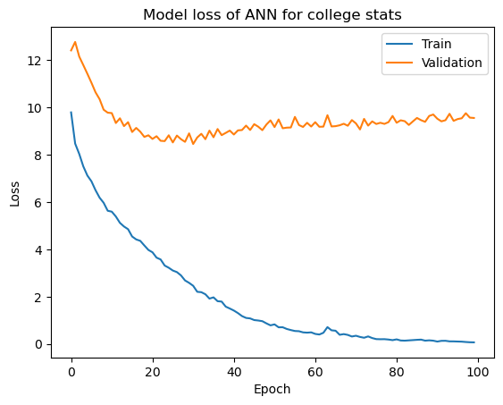

```python
# Visualizing Training history
import matplotlib.pyplot as plt

# Plot training & validation loss values
plt.plot(history_college.history['loss'])
plt.plot(history_college.history['val_loss'])
plt.title('Model loss of ANN for college stats')
plt.xlabel('Epoch')
plt.ylabel('Loss')
plt.legend(['Train', 'Validation'], loc='upper right')
plt.show()
```

```python
# From the above plot, we can say that the model overfits.
```

```python
# L2 Regularization to reduce over fitting

from keras.regularizers import l2

# Define the neural network architecture with L2 regularization
model_college_ann_l2 = Sequential()

# Input layer and first hidden layer with 64 neurons, ReLU activation, and L2 regularization
model_college_ann_l2.add(Dense(64, input_dim=X_college_train_scaled.shape[1], activation='relu',
                kernel_regularizer=l2(0.01)))  # L2 regularization with factor 0.01

# Additional hidden layers with L2 regularization
model_college_ann_l2.add(Dense(128, activation='relu', kernel_regularizer=l2(0.01)))
model_college_ann_l2.add(Dense(64, activation='relu', kernel_regularizer=l2(0.01)))

# Output layer with 1 neuron (for regression)
model_college_ann_l2.add(Dense(1, activation='linear'))

# Compile the model
model_college_ann_l2.compile(optimizer=Adam(learning_rate=0.001), loss='mean_squared_error', metrics=['mse'])
```

```python
# Train the model
history_college_l2 = model_college_ann_l2.fit(X_college_train_scaled, y_college_train, validation_split=0.2, epochs=100, batch_size=32, verbose=1)
```

```python
# Predict BPM values for the test set
y_pred_college_ann_l2 = model_college_ann_l2.predict(X_college_test_scaled)

# Evaluate the model's performance
mse_college_ann_l2 = mean_squared_error(y_college_test, y_pred_college_ann_l2)
r2_college_ann_l2 = r2_score(y_college_test, y_pred_college_ann_l2)

print(f'Mean Squared Error: {mse_college_ann_l2}')
print(f'R-squared: {r2_college_ann_l2}')
```

```
Mean Squared Error: 10.912001593694319
R-squared: 0.15631857238726943
```

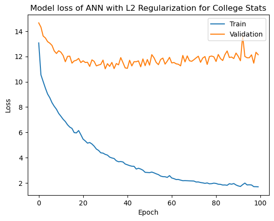

```python
# Visualizing Training history
import matplotlib.pyplot as plt

# Plot training & validation loss values
plt.plot(history_college_l2.history['loss'])
plt.plot(history_college_l2.history['val_loss'])
plt.title('Model loss of ANN with L2 Regularization for College Stats')
plt.xlabel('Epoch')
plt.ylabel('Loss')
plt.legend(['Train', 'Validation'], loc='upper right')
plt.show()
```

```python
# The model with l2 regularization overfits more than the same model without l2 regularization.
```

### Deep Neural Network (DNN) for college stats

```python
# Names of the split data set = X_college_train, X_college_test, y_college_train, y_college_test
```

```python
import numpy as np
import pandas as pd
from sklearn.model_selection import train_test_split
from sklearn.preprocessing import StandardScaler
from sklearn.metrics import mean_squared_error, r2_score
import tensorflow as tf
from tensorflow.keras.models import Sequential
from tensorflow.keras.layers import Dense, Dropout
from tensorflow.keras.optimizers import Adam
```

```python
# Feature Scaling

scaler = StandardScaler()

# Scale the training data
X_college_train_scaled = scaler.fit_transform(X_college_train)

# Scale the test data
X_college_test_scaled = scaler.transform(X_college_test)
```

```python
# Initialize the model
model_college_dnn = Sequential()

# Input layer and first hidden layer with 64 neurons and ReLU activation
model_college_dnn.add(Dense(64, input_dim=X_college_train_scaled.shape[1], activation='relu'))

# Additional hidden layers
model_college_dnn.add(Dense(128, activation='relu'))
model_college_dnn.add(Dropout(0.3))  # Dropout layer to prevent overfitting
model_college_dnn.add(Dense(64, activation='relu'))

# Output layer with a single neuron (since this is a regression problem)
model_college_dnn.add(Dense(1, activation='linear'))

# Compile the model with mean squared error loss and the Adam optimizer
model_college_dnn.compile(optimizer=Adam(learning_rate=0.001), loss='mean_squared_error', metrics=['mse'])
```

```python
# Train the model
history_college = model_college_dnn.fit(X_college_train_scaled, y_college_train, validation_split=0.2, epochs=100, batch_size=32, verbose=1)
```

```python
# Predict BPM values for the test set
y_pred_college_dnn = model_college_dnn.predict(X_college_test_scaled)

# Evaluate the model's performance
mse_college_dnn = mean_squared_error(y_college_test, y_pred_college_dnn)
r2_college_dnn = r2_score(y_college_test, y_pred_college_dnn)

print(f'Mean Squared Error: {mse_college_dnn}')
print(f'R-squared: {r2_college_dnn}')
```

```
Mean Squared Error: 11.78634748422731
R-squared: 0.08871691536602488
```

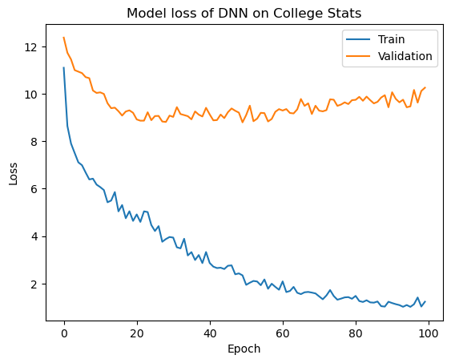

```python
import matplotlib.pyplot as plt

# Plot training & validation loss values
plt.plot(history_college.history['loss'])
plt.plot(history_college.history['val_loss'])
plt.title('Model loss of DNN on College Stats')
plt.xlabel('Epoch')
plt.ylabel('Loss')
plt.legend(['Train', 'Validation'], loc='upper right')
plt.show()
```

```python
# The above model overfits.
```

```python
# L2 Regularization

import tensorflow as tf
from tensorflow.keras import layers, models, regularizers

# Define the model architecture with L2 regularization
model_college_dnn_l2 = models.Sequential()

# Input layer and first hidden layer with 64 neurons, ReLU activation, and L2 regularization
model_college_dnn_l2.add(Dense(64, input_dim=X_college_train_scaled.shape[1], activation='relu',
                kernel_regularizer=l2(0.001)))  # L2 regularization with factor 0.001

# Hidden layers with L2 regularization
model_college_dnn_l2.add(layers.Dense(128, activation='relu', kernel_regularizer=regularizers.l2(0.001)))
model_college_dnn_l2.add(layers.Dense(64, activation='relu', kernel_regularizer=regularizers.l2(0.001)))
model_college_dnn_l2.add(layers.Dense(32, activation='relu', kernel_regularizer=regularizers.l2(0.001)))

# Output layer for regression (for predicting BPM)
model_college_dnn_l2.add(layers.Dense(1))  # Single output for regression

# Compile the model
model_college_dnn_l2.compile(optimizer='adam',
              loss='mean_squared_error',  # For regression
              metrics=['mae'])  # Mean Absolute Error as an additional metric
```

```python
history_college_l2 = model_college_dnn_l2.fit(X_college_train_scaled, y_college_train, validation_split=0.2, epochs=100, batch_size=32, verbose=1)
```

```python
# Predict BPM values for the test set
y_pred_college_dnn_l2 = model_college_dnn_l2.predict(X_college_test_scaled)

# Evaluate the model's performance
mse_college_dnn_l2 = mean_squared_error(y_college_test, y_pred_college_dnn_l2)
r2_college_dnn_l2 = r2_score(y_college_test, y_pred_college_dnn_l2)

print(f'Mean Squared Error: {mse_college_dnn_l2}')
print(f'R-squared: {r2_college_dnn_l2}')
```

```
Mean Squared Error: 12.200869498816388
R-squared: 0.05666738512699776
```

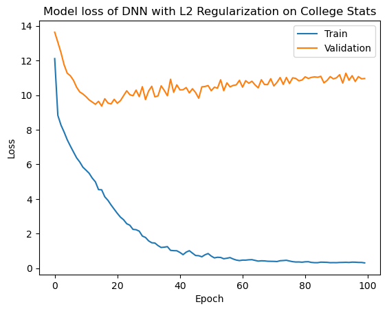

```python
import matplotlib.pyplot as plt

# Plot training & validation loss values
plt.plot(history_college_l2.history['loss'])
plt.plot(history_college_l2.history['val_loss'])
plt.title('Model loss of DNN with L2 Regularization on College Stats')
plt.xlabel('Epoch')
plt.ylabel('Loss')
plt.legend(['Train', 'Validation'], loc='upper right')
plt.show()
```

```python
# This model overfits.
```

#### Decision Tree Regressor for Predicting BPM Based on College Stats

```python
# Names of the split data set = X_college_train, X_college_test, y_college_train, y_college_test
```

```python
import numpy as np
import pandas as pd
from sklearn.model_selection import train_test_split
from sklearn.preprocessing import StandardScaler
from sklearn.tree import DecisionTreeRegressor
from sklearn.metrics import mean_squared_error, r2_score
```

```python
# Feature Scaling

scaler = StandardScaler()

# Scale the training data
X_college_train_scaled = scaler.fit_transform(X_college_train)

# Scale the test data
X_college_test_scaled = scaler.transform(X_college_test)
```

```python
# Initialize the Decision Tree Regressor
model_college_dtr = DecisionTreeRegressor(random_state=42)

# Train the model
model_college_dtr.fit(X_college_train_scaled, y_college_train)
```

```
DecisionTreeRegressor(random_state=42)
```

```python
# Predict BPM values for the test set
y_pred_college_dtr = model_college_dtr.predict(X_college_test_scaled)

# Evaluate the model's performance
mse_college_dtr = mean_squared_error(y_college_test, y_pred_college_dtr)
r2_college_dtr = r2_score(y_college_test, y_pred_college_dtr)

print(f'Mean Squared Error: {mse_college_dtr}')
print(f'R-squared: {r2_college_dtr}')
```

```
Mean Squared Error: 18.72188235294118
R-squared: -0.44751669027014973
```

```python
# The models evern performs than baseline model.
```

```python
# Hyperparameter Tuning
from sklearn.model_selection import GridSearchCV

# Define the parameter grid
param_grid = {
    'max_depth': [3, 5, 10, None],
    'min_samples_split': [2, 5, 10],
    'min_samples_leaf': [1, 2, 4]
}

# Initialize GridSearchCV
grid_search = GridSearchCV(DecisionTreeRegressor(random_state=42), param_grid, cv=5, scoring='neg_mean_squared_error')

# Fit the grid search
grid_search.fit(X_college_train_scaled, y_college_train)

# Best parameters
print(f"Best Parameters: {grid_search.best_params_}")

# Use the best model
best_model_college_dtr_tune = grid_search.best_estimator_

# Predict using the best model
y_pred_best_college_dtr_tune = best_model_college_dtr_tune.predict(X_college_test_scaled)

# Evaluate the best model
mse_best_college_dtr_tune = mean_squared_error(y_college_test, y_pred_best_college_dtr_tune)
r2_best_college_dtr_tune = r2_score(y_college_test, y_pred_best_college_dtr_tune)

print(f"Best Mean Squared Error: {mse_best_college_dtr_tune}")
print(f"Best R-squared: {r2_best_college_dtr_tune}")
```

```
Best Parameters: {'max_depth': 3, 'min_samples_leaf': 2, 'min_samples_split': 2}
Best Mean Squared Error: 13.259010986992665
Best R-squared: -0.025144765805669156
```

```python
# The model hasn't performed better than the mean baseline model.
```